# Manual eScriptorium: Primeros pasos

José Manuel Fradejas Rueda

Filología Digital UVa

2025-07-03

[figure not shown]

# Manual de eScriptorium

## Primeros pasos

Este manual está pensado para ayudar a los usuarios a familiarizarse con el uso de eScriptorium, una herramienta de transcripción y edición de textos históricos. A través de este manual, se proporcionarán instrucciones detalladas sobre cómo utilizar las diferentes funcionalidades de la plataforma.

Si tienes una cuenta activa en la instancia `eScriptorium` de la Universidad de Valladolid, puedes acceder a la plataforma con este enlace http://escriptorium.eca-simm.uva.es/.

Aparecerá una pantalla de inicio de sesión donde deberás introducir tu usuario y contraseña.

[figure not shown]

Para introducirlo, puedes hacer clic en botón `Sign in` que hay en la parte superior de la página o en el botón más pequeño que hay en la parte inferior de la barra blanca de la izquierda. Cuando hayas hecho clic en cualquiera de los dos, aparecerán las casillas para que introduzcas tu usuario y contraseña.

[figure not shown]

Una vez introducidos los datos, pulsa el botón `login` y accederás a la página principal de `eScriptorium` (lo reducimos a la abreviatura `eS`).

[figure not shown]

La página `Home` es casi idéntica a la de página en la que pulsate en `Sign in`, solo que en la barra lateral izquierda tienes todos elementos básicos de navegación.

Pulsa sobre `Profile`.

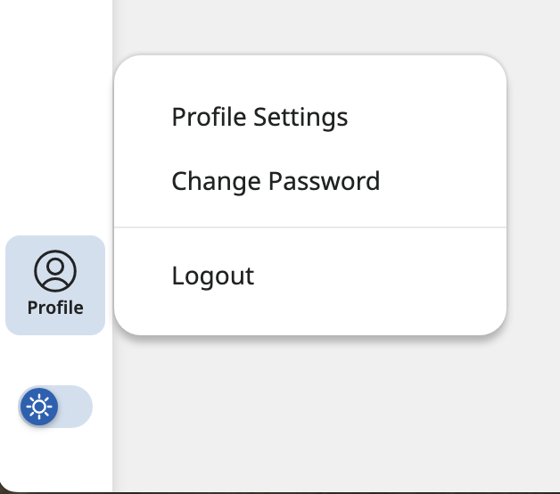

Se abrirá una ventanita con tres posibilidades. haz clic en la que dice `Profile Settings`. Aparecerá una página con tu perfil, donde podrás ver tu correo electrónico mientras que las demás casillas estarán vacías. Rellana la de tu nombre y apellidos. Si no lo haces, para la máquina serás el nombre del usuario que has introducido al entrar.

[figure not shown]

Si haces clic en la casilla `Legacy mode` aparecerá un aspecto diferente de la plataforma. Vamos a emplearlo a lo largo de todo este manual. Así que haz clic en él y pulsa el botón `Save`.

El aspecto de la página habrá cambiado y el menú ya no estára en el margen izquierdo, sino en la barra superior, en una franja de color negro.

[figure not shown]

Si pulsas sobre `API key` aparecerá una ventana con un código. Este código es importante, ya que te permitirá acceder a la API de `eS` y realizar tareas automatizadas. Por el momento no lo vas a utilizar, es para usuarios avanzados, y estás dando los primeros pasos.

En `Files` encontrarás la lista de los ficheros que has pedido a `eS` que descargue. Por ahora debería estar vacío, ya que no has le has pedido que descargue ninguno.

En `Teams` podrás ver los equipos a los que perteneces. Si no perteneces a ninguno, aparecerá vacío. Pero puedes crear uno nuevo. Solo tienes que darle un nombre y hacer clic en `Create`. Por el momento, no hagas nada.

Por último, tiene `Invitations`, donde podrás ver las invitaciones que has enviado o recibido para unirte a un equipo. Aparecerá en blanco, con un cartelito que te informará de que no tienes invitaciones aún.

En la nueva visión de `eS`, la barra negra de arriba tiene un menú desplegable que te permite acceder a las diferentes secciones de la plataforma. En la parte derecha, tienes tu nombre de usuario y un botón para abrir el desplegable que antes tenías abajo a la izquierda.

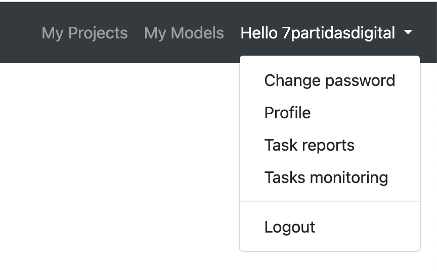

Es importante que cambies la contraseña de tu cuenta. Para ello, haz clic en `Change password`. Aparecerá una ventana donde podrás introducir tu contraseña actual y la nueva. Introduce la nueva contraseña dos veces para confirmarla y haz clic en `Change my password`.

Un botón importante del menú desplegabla, es el de salida, `Logout`. Cuando quieras salir de `eS`, haz clic en él y se cerrará la sesión.